# TIP-RA Baseline: ACPA Presence Analysis For Paper

Lauren Vanderlinden

Report generated: July 22, 2022

# Introduction

This is updating the unstratified analysis performed for the paper. We previously used a continuous measure for ACPA as the outcome, and here we will be modeling ACPA as either positive or negative.

## ACPA Positivity

Instead of modeling ACPA abundance, we are going to model ACPA presence (yes or no). The criteria to determine ACPA positivity will be defined as the mean + 3 SD based on the control (CCP negative) group. Apply this across all subjects to get a positive/negative call for each ACPA peptide. **Note:** Not going to perform this on the aggregate measures.

## Analysis Approach

Will perform a **logistic regression** using group (either CCP-, CCP+ or early RA) to predict ACPA positivity adjusting for age, sex and ever a smoker status. Multiple testing adjustment was accounted for using the Bemjamini Hochberg false discovery rate (FDR) method on the F-test p-value for group effect. Pairwise comparisons are reported.

# Demographics

This is the demographic table used for the analysis. This is just for reference and the total N’s for these groups are what I added to supplemental table 5. For the N’s in supplemental table 6, I looked at the N’s within the ‘0401Count’.

|  | CCP_Neg_Baseline (N=172) | CCP_Pos_Baseline (N=97) | RA_Baseline (N=62) | Overall (N=331) |
| --- | --- | --- | --- | --- |
| SE |  |  |  |  |
| Neg | 91 (52.9%) | 48 (49.5%) | 22 (35.5%) | 161 (48.6%) |
| Pos | 81 (47.1%) | 49 (50.5%) | 40 (64.5%) | 170 (51.4%) |
| as.factor(SECount) |  |  |  |  |
| 0 | 91 (52.9%) | 47 (48.5%) | 22 (35.5%) | 160 (48.3%) |
| 1 | 70 (40.7%) | 39 (40.2%) | 30 (48.4%) | 139 (42.0%) |
| 2 | 11 (6.4%) | 11 (11.3%) | 10 (16.1%) | 32 (9.7%) |
| as.factor(`0401Count`) |  |  |  |  |
| 0 | 139 (80.8%) | 71 (73.2%) | 38 (61.3%) | 248 (74.9%) |
| 1 | 32 (18.6%) | 25 (25.8%) | 23 (37.1%) | 80 (24.2%) |
| 2 | 1 (0.6%) | 1 (1.0%) | 1 (1.6%) | 3 (0.9%) |
| EverSmoke |  |  |  |  |
| No | 113 (65.7%) | 62 (63.9%) | 29 (46.8%) | 204 (61.6%) |
| Yes | 59 (34.3%) | 35 (36.1%) | 33 (53.2%) | 127 (38.4%) |
| Gender |  |  |  |  |
| Female | 117 (68.0%) | 63 (64.9%) | 41 (66.1%) | 221 (66.8%) |
| Male | 54 (31.4%) | 34 (35.1%) | 21 (33.9%) | 109 (32.9%) |
| Transgender | 1 (0.6%) | 0 (0%) | 0 (0%) | 1 (0.3%) |
| Age |  |  |  |  |
| Mean (SD) | 57.8 (12.6) | 58.5 (12.6) | 51.8 (12.9) | 56.9 (12.9) |
| Median [Min, Max] | 61.0 [22.0, 78.0] | 62.0 [18.0, 83.0] | 54.0 [20.0, 77.0] | 60.0 [18.0, 83.0] |

# Unstratified ACPA Positivity Analysis

This is the basic logistic model with group (either CCP-, CCP+ or early RA) predicting ACPA positivity while adjusting for age, sex and ever smoker status.

## Criteria Distribution

Just a quick glance at how distriution of different positivity crtieria. So depending on the ACPA peptide you are looking at, we could have a positivity criteria ranging from 496 to 4,092.

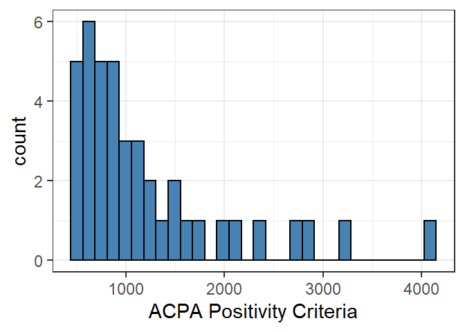

## Results Table

I’m showing the number of ACPA positive (%) in each group and the p-values. This is similar to the means and p-values reported in other supplemental tables.

If you want a table with odds ratios, 95% CI as well, let me know and I’ll create that.

|  | Anti-CCP3 | At-Risk | Early RA | overall p-value | At-Risk vs Anti-CCP3 p-value (FDR) | Early RA vs At-Risk p-value (FDR) |
| --- | --- | --- | --- | --- | --- | --- |
| CILP 536-552 cit 544 (19) | 2 (2.06%) | 0 (0%) | 7 (11.29%) | 3.91e-04 | 1.00e+00 (1) | 1.00e+00 (1) |
| CILP 982-996 cit 988 991 (54) | 4 (4.12%) | 4 (2.33%) | 12 (19.35%) | 7.66e-05 | 7.08e-01 (1) | 9.83e-03 (0.029) |
| CILP 775-792 cit 783 (93) | 3 (3.09%) | 1 (0.58%) | 4 (6.45%) | 1.03e-01 | 8.73e-01 (1) | 1.85e-01 (0.362) |
| CILP 17-31 cit 22 (89) | 4 (4.12%) | 2 (1.16%) | 9 (14.52%) | 1.58e-03 | 9.95e-01 (1) | 2.56e-02 (0.062) |
| CILP 297-311 cit 305 (84) | 4 (4.12%) | 1 (0.58%) | 5 (8.06%) | 2.76e-02 | 7.39e-01 (1) | 7.74e-02 (0.176) |
| CILP 536-552 (91) | 1 (1.03%) | 0 (0%) | 0 (0%) | 5.45e-01 | 1.00e+00 (1) | 1.00e+00 (1) |
| CILP 982-996 (21) | 1 (1.03%) | 0 (0%) | 0 (0%) | 5.45e-01 | 1.00e+00 (1) | 1.00e+00 (1) |
| CILP 775-792 (44) | 4 (4.12%) | 1 (0.58%) | 3 (4.84%) | 1.78e-01 | 7.33e-01 (1) | 2.07e-01 (0.386) |
| CILP 17-31 (90) | 4 (4.12%) | 2 (1.16%) | 4 (6.45%) | 3.22e-01 | 9.89e-01 (1) | 4.06e-01 (0.594) |
| CILP 297-311 (28) | 3 (3.09%) | 1 (0.58%) | 3 (4.84%) | 2.46e-01 | 8.80e-01 (1) | 3.03e-01 (0.477) |

[output cut: 31 more lines]

## Candidate

Lets look at the bar charts for this peptide:

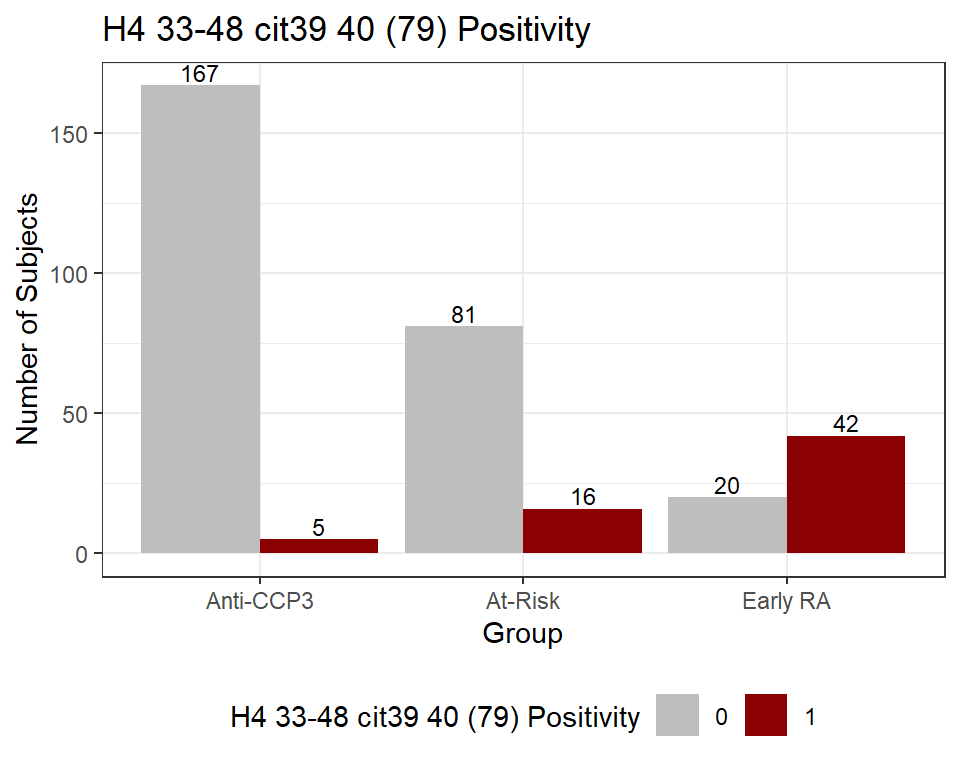

## Heatmap for Paper

Probably just use Kevin’s, but here it one I made for the report.

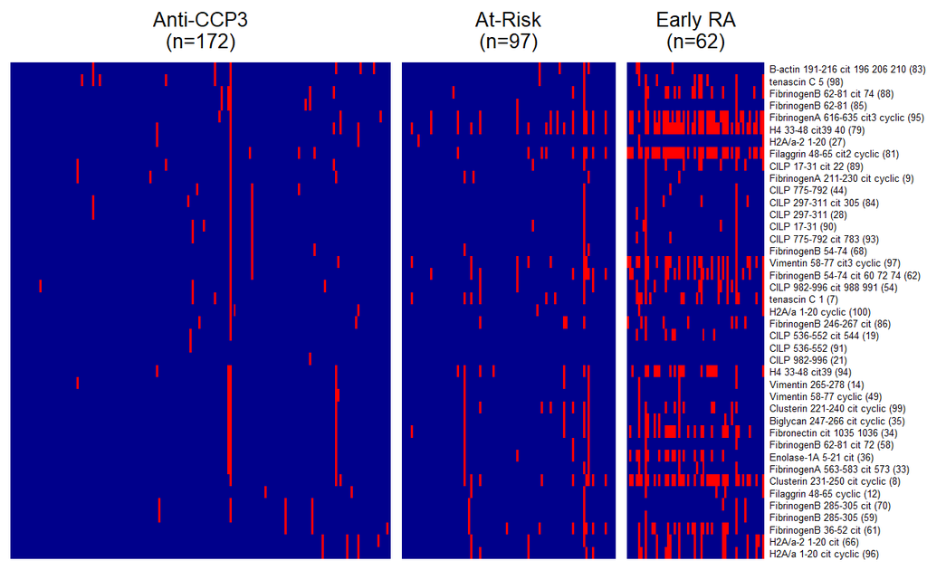

# Stratified ACPA Positivity Analysis

Here we are going to stratify the dataIn by **0401 positivity**. In the dataset, we have it counted as either 0, 1, or 2. But we are stratifying into 2 groups: either 0 or at least 1.

## Distribution of 0401 genotype

Here is the table of the 0401 genotype in our dataset. It is classified as either 0, 1 or 2 copies of the 0401 allele. But as we can see the 2 copies are fairly rare, so we are going to stratify the data by 0 copies or at least 1 copy of the 0401 allele.

| Number of 0401 Alleles | 0401 Negative | 0401 Positive |
| --- | --- | --- |
| 0 | 248 | 0 |
| 1 | 0 | 80 |
| 2 | 0 | 3 |

Of the stratified results comparing CCP- and CCP+, nothing reached FDR < 0.05 criteria. None of the positive 0401 genotype results even met a nominal p-value < 0.05 (minimum p-value for this strata is 0.179). However, for the negative 0401 genotype strata, there are **5** ACPA peptides with a nominal p-value < 0.05. They are: FibrinogenA 616-635 cit3 cyclic (95), FibrinogenB 36-52 cit (61), FibrinogenB 54-74 cit 60 72 74 (62), Clusterin 231-250 cit cyclic (8), H4 33-48 cit39 40 (79).

## 0401 Positive Results Table

| ACPA Feature | Anti-CCP3 | At-Risk | Early RA | At-Risk vs Anti-CCP3 p-value (FDR) | Early RA vs At-Risk p-value (FDR) |
| --- | --- | --- | --- | --- | --- |
| B-actin 191-216 cit 196 206 210 (83) | 2 (7.69%) | 1 (3.03%) | 2 (8.33%) | 8.96e-01 (1) | 9.30e-01 (1) |
| Biglycan 247-266 cit cyclic (35) | 1 (3.85%) | 2 (6.06%) | 4 (16.67%) | 7.58e-01 (1) | 2.36e-01 (0.484) |
| CILP 17-31 (90) | 2 (7.69%) | 0 (0%) | 3 (12.5%) | 1.00e+00 (1) | 5.64e-01 (0.77) |
| CILP 17-31 cit 22 (89) | 2 (7.69%) | 0 (0%) | 5 (20.83%) | 1.00e+00 (1) | 1.37e-01 (0.33) |
| CILP 297-311 (28) | 1 (3.85%) | 0 (0%) | 2 (8.33%) | 1.00e+00 (1) | 3.78e-01 (0.619) |
| CILP 297-311 cit 305 (84) | 1 (3.85%) | 0 (0%) | 3 (12.5%) | 1.00e+00 (1) | 2.52e-01 (0.491) |
| CILP 536-552 (91) | 1 (3.85%) | 0 (0%) | 0 (0%) | 1.00e+00 (1) | 1.00e+00 (1) |
| CILP 536-552 cit 544 (19) | 2 (7.69%) | 0 (0%) | 4 (16.67%) | 1.00e+00 (1) | 4.17e-01 (0.658) |
| CILP 775-792 (44) | 2 (7.69%) | 0 (0%) | 2 (8.33%) | 1.00e+00 (1) | 5.24e-01 (0.767) |
| CILP 775-792 cit 783 (93) | 2 (7.69%) | 0 (0%) | 2 (8.33%) | 1.00e+00 (1) | 6.82e-01 (0.847) |

[output cut: 31 more lines]

## 0401 Negative Results Table

| ACPA Feature | Anti-CCP3 | At-Risk | Early RA | At-Risk vs Anti-CCP3 p-value (FDR) | Early RA vs At-Risk p-value (FDR) |
| --- | --- | --- | --- | --- | --- |
| B-actin 191-216 cit 196 206 210 (83) | 4 (5.63%) | 3 (2.16%) | 1 (2.63%) | 8.02e-01 (1) | 9.99e-01 (1) |
| Biglycan 247-266 cit cyclic (35) | 2 (2.82%) | 2 (1.44%) | 4 (10.53%) | 7.88e-01 (1) | 3.81e-02 (0.111) |
| CILP 17-31 (90) | 2 (2.82%) | 2 (1.44%) | 1 (2.63%) | 7.06e-01 (1) | 9.05e-01 (1) |
| CILP 17-31 cit 22 (89) | 2 (2.82%) | 2 (1.44%) | 4 (10.53%) | 7.11e-01 (1) | 5.34e-02 (0.146) |
| CILP 297-311 (28) | 2 (2.82%) | 1 (0.72%) | 1 (2.63%) | 1.00e+00 (1) | 8.88e-01 (1) |
| CILP 297-311 cit 305 (84) | 3 (4.23%) | 1 (0.72%) | 2 (5.26%) | 9.41e-01 (1) | 3.58e-01 (0.7) |
| CILP 536-552 (91) | 0 (0%) | 0 (0%) | 0 (0%) | 1.00e+00 (1) | 1.00e+00 (1) |
| CILP 536-552 cit 544 (19) | 0 (0%) | 0 (0%) | 3 (7.89%) | 1.00e+00 (1) | 1.00e+00 (1) |
| CILP 775-792 (44) | 2 (2.82%) | 1 (0.72%) | 1 (2.63%) | 9.99e-01 (1) | 8.02e-01 (1) |
| CILP 775-792 cit 783 (93) | 1 (1.41%) | 1 (0.72%) | 2 (5.26%) | 8.50e-01 (1) | 2.60e-01 (0.532) |

[output cut: 31 more lines]

## Heatmaps

**0401 Positive Strata**

[figure not shown]

**0401 Negative Strata**

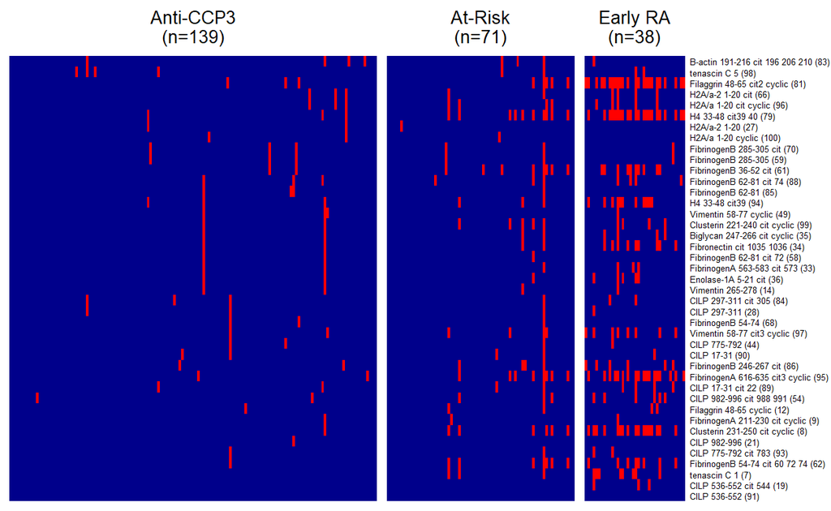

# Alternative Heatmap

This is an alternative heatmap. This has all samples, but added a bar on top of each to signify if the same is genotype 0401 positive (yellow) or 0401 negative (green).

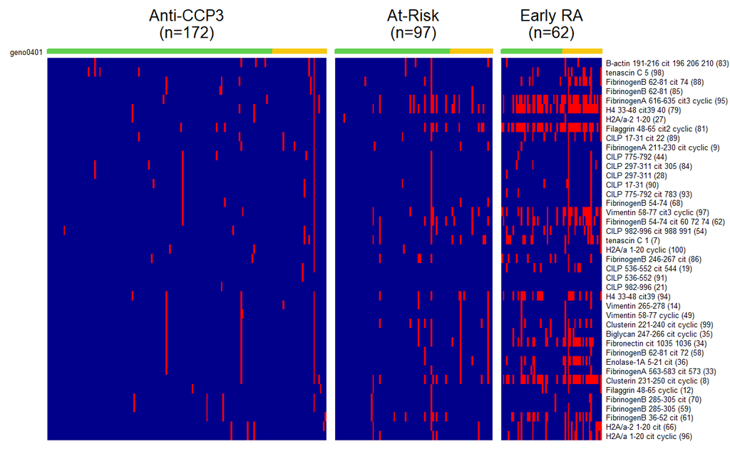